# TPC5

João Dias

2023-10-23

### a.

Qual é a probabilidade de a empresa solicitar no máximo 1650 metros cúbicos num determinado pedido?

#### a1

Determine este valor exatamente

```r
pnorm(1650, mean = 1500, sd = 100)
```

```
## [1] 0.9331928
```

#### a2

Obtenha uma aproximação a este valor com base numa simulação de 1000 pedidos

```r
simul <- rnorm(1000, mean = 1500, sd = 100)

count_1 <- length(which(simul <= 1650))

aprox_prob <- count_1/1000

aprox_prob
```

```
## [1] 0.949
```

### b.

Qual o menor número de metros cúbicos dos 5% maiores consumos?

#### b1

Determine este valor exatamente

```r
qnorm(0.95, mean = 1500, sd = 100)
```

```
## [1] 1664.485
```

#### b2

Obtenha uma aproximação a este valor com base numa simulação de 1000 pedidos

```r
quantile(simul, 0.95)
```

```
##      95%
## 1650.597
```

### c.

Admita que, entre maio e outubro, a empresa faz 40 pedidos de água à barragem. Qual a probabilidade de 10 ou mais destes pedidos serem de pelo menos 1650 m3?

#### c1

Defina a variável aleatória de interesse e represente graficamente a respetiva função de probabilidade.

X - número de pedidos de água que foram de pelo menos 1650m3, entre os 40 pedidos recebidos

```r
prob <- pnorm(1650, mean = 1500, sd = 100, lower.tail = FALSE)
prob
```

```
## [1] 0.0668072
```

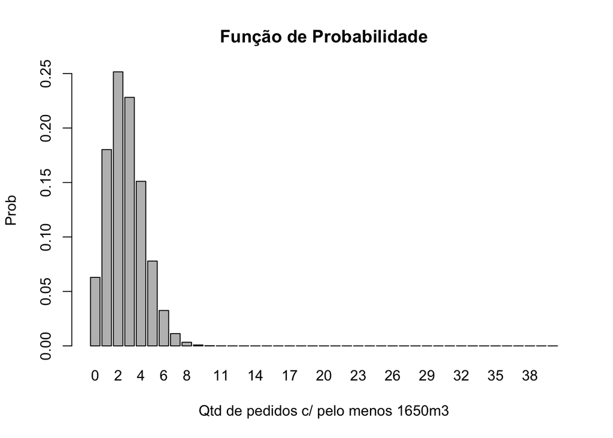

```r
x <- 0:40
y <- dbinom(x, size = 40, prob = prob)

barplot(y, names.arg = x, xlab = "Qtd de pedidos c/ pelo menos 1650m3", ylab = "Prob", main = "Função de Probabilidade")
```

#### c2

Especifique teoricamente a probabilidade pretendida e calcule-a.

A variável X definida em c1 apresenta uma distribuição binomial, o que significa que é possível calcular a probabilidade de obter um determinado número de pedidos de pelo menos 1650 m3. No caso específico, estamos interessados na probabilidade de haver 10 ou mais pedidos destes pedidos e para este cálculo podemos usar a função pbinom.

```r
pbinom(9, size = 40, prob = prob, lower.tail = F)
```

```
## [1] 0.0002329601
```

#### c3

Em média, quantos pedidos em 40 estão nestas condições?

```r
40*prob
```

```
## [1] 2.672288
```